# Jupyter Notebook Cybersecurity Hunting - Web Proxy Logs

This Jupyter Notebook uses sample web proxy logs as the data source to perform quick threat hunting, analytics and reporting.

The data set used in this Jupyter Notebook is from: http://log-sharing.dreamhosters.com/bluecoat_proxy_big.zip.

### Import Libraries

```python
import pandas as pd
# data analysis and manipulation tool

import os
# operating system interface

import whois
#https://anaconda.org/rapidsai/python-whois

import pandas_profiling
from pandas_profiling import ProfileReport
from pandas_profiling.utils.cache import cache_file
#https://anaconda.org/conda-forge/pandas-profiling
```

```python
import sys
!{sys.executable} -m pip install -U pandas-profiling[notebook]
!jupyter nbextension enable --py widgetsnbextension

import pandas as pd
from pandas_profiling import ProfileReport
```

[output not shown]

```python
import numpy as np
# mathematical functions

import matplotlib.pyplot as plt
# creating static, animated, and interactive visualizations

%matplotlib inline
# renders static images

# %matplotlib notebook
# renders dynamic interactive images
```

#### Identify Your Notebook's System Location

```python
os.getcwd()
# print current working directory
```

```
'C:\\Users\\IEUser\\Documents\\Jupyter'
```

#### Determine the Size of Proxy Log File

```python
file_size = os.path.getsize('C:\\Users\\IEUser\\Documents\\Jupyter\\Demo_log_004.log')
#read the size of the log file

print (file_size >> 20)
print("MB")
# use bitshift to convert from bytes to other unit
# >> 10 KB
# >> 20 MB
# >> 30 GB
```

```
60
MB
```

### Load Data

```python
df = pd.read_csv('C:\\Users\\IEUser\\Documents\\Jupyter\\Demo_log_004.log', encoding='latin1', engine='python', sep=' ',error_bad_lines=False)
#load data
df
```

[output not shown]

[output cut: 462 more lines]

[output not shown]

|  | date | time | time-taken | c-ip | sc-status | s-action | sc-bytes | cs-bytes | cs-method | cs-uri-scheme | ... | rs(Content-Type) | cs(User-Agent) | sc-filter-result | sc-filter-category | x-virus-id | s-ip | s-sitename | x-virus-details | x-icap-error-code | x-icap-error-details |
| --- | --- | --- | --- | --- | --- | --- | --- | --- | --- | --- | --- | --- | --- | --- | --- | --- | --- | --- | --- | --- | --- |
| 0 | 2005-04-05 | 18:27:21 | 75 | 10.0.1.2 | 200.0 | TCP_NC_MISS | 186.0 | 231.0 | GET | http | ... | text/html | Mozilla/4.0 (compatible; ProxyAV) | PROXIED | none | - | 10.2.13.200 | SG-HTTP-Service | - | none | - |
| 1 | 2005-04-05 | 18:36:57 | 157 | 10.0.1.2 | 200.0 | TCP_CLIENT_REFRESH | 372.0 | 247.0 | GET | http | ... | application/octet-stream | Mozilla/4.0 (compatible; ProxyAV) | PROXIED | none | - | 10.2.13.200 | SG-HTTP-Service | - | none | - |
| 2 | 2005-04-05 | 18:36:57 | 226 | 10.0.1.2 | 200.0 | TCP_CLIENT_REFRESH | 388.0 | 248.0 | GET | http | ... | application/octet-stream | Mozilla/4.0 (compatible; ProxyAV) | PROXIED | none | - | 10.2.13.200 | SG-HTTP-Service | - | none | - |
| 3 | 2005-04-05 | 18:52:57 | 106 | 10.0.1.2 | 200.0 | TCP_NC_MISS | 234.0 | 213.0 | GET | http | ... | text/html | Mozilla/4.0 (compatible; ProxyAV) | PROXIED | none | - | 10.2.13.200 | SG-HTTP-Service | - | none | - |
| 4 | 2005-04-05 | 18:54:01 | 133 | 10.0.1.2 | 200.0 | TCP_NC_MISS | 521.0 | 508.0 | GET | http | ... | text/html | Mozilla/4.0 (compatible; ProxyAV) | PROXIED | none | - | 10.2.13.200 | SG-HTTP-Service | - | none | - |
| ... | ... | ... | ... | ... | ... | ... | ... | ... | ... | ... | ... | ... | ... | ... | ... | ... | ... | ... | ... | ... | ... |
| 195239 | 2005-05-06 | 23:40:36 | 105 | 45.0.0.121 | 302.0 | TCP_NC_MISS | 616.0 | 985.0 | GET | http | ... | text/html;%20charset=iso-8859-1 | Mozilla/5.0 (Windows; U; Windows NT 5.1; en-US... | PROXIED | Web%20Advertisements | - | 192.16.170.44 | SG-HTTP-Service | - | none | - |
| 195240 | 2005-05-06 | 23:40:57 | 79 | 45.0.0.121 | 200.0 | TCP_RESCAN_HIT | 259.0 | 619.0 | GET | http | ... | image/gif | Mozilla/5.0 (Windows; U; Windows NT 5.1; en-US... | PROXIED | none | - | 192.16.170.44 | SG-HTTP-Service | - | none | - |
| 195241 | 2005-05-06 | 23:40:59 | 3 | 45.0.0.121 | 200.0 | TCP_RESCAN_HIT | 259.0 | 645.0 | GET | http | ... | image/gif | Mozilla/5.0 (Windows; U; Windows NT 5.1; en-US... | PROXIED | none | - | 192.16.170.44 | SG-HTTP-Service | - | none | - |
| 195242 | 2005-05-06 | 23:46:13 | 54 | 10.0.1.7 | 200.0 | TCP_CLIENT_REFRESH | 387.0 | 248.0 | GET | http | ... | application/octet-stream | Mozilla/4.0 (compatible; ProxyAV) | PROXIED | Computers/Internet | - | 192.16.170.44 | SG-HTTP-Service | - | none | - |
| 195243 | 2005-05-06 | 23:46:13 | 141 | 10.0.1.7 | 200.0 | TCP_CLIENT_REFRESH | 372.0 | 247.0 | GET | http | ... | application/octet-stream | Mozilla/4.0 (compatible; ProxyAV) | PROXIED | Computers/Internet | - | 192.16.170.44 | SG-HTTP-Service | - | none | - |

195244 rows × 26 columns

#### Confirm a Successful Data Load

```python
df.shape
#Returns tuple of shape (Rows, columns) of dataframe/series
```

```
(195244, 26)
```

### Data Exploration

Exploratory Data Analysis: understanding the data at a high-level and summarize its main characteristics

```python
df.columns
# read just headers
```

```
Index(['date', 'time', 'time-taken', 'c-ip', 'sc-status', 's-action',
       'sc-bytes', 'cs-bytes', 'cs-method', 'cs-uri-scheme', 'cs-host',
       'cs-uri-path', 'cs-uri-query', 'cs-username', 's-hierarchy',
       's-supplier-name', 'rs(Content-Type)', 'cs(User-Agent)',
       'sc-filter-result', 'sc-filter-category', 'x-virus-id', 's-ip',
       's-sitename', 'x-virus-details', 'x-icap-error-code',
       'x-icap-error-details'],
      dtype='object')
```

```python
#basic information of the data such as total columns, total entries, data types
df.info()
```

```
<class 'pandas.core.frame.DataFrame'>
RangeIndex: 195244 entries, 0 to 195243
Data columns (total 26 columns):
 #   Column                Non-Null Count   Dtype
---  ------                --------------   -----
 0   date                  195244 non-null  object
 1   time                  195244 non-null  object
 2   time-taken            194731 non-null  object
 3   c-ip                  193705 non-null  object
 4   sc-status             193705 non-null  float64
 5   s-action              193705 non-null  object
 6   sc-bytes              193705 non-null  float64
 7   cs-bytes              193705 non-null  float64
 8   cs-method             193705 non-null  object
 9   cs-uri-scheme         193705 non-null  object
```

[output cut: 18 more lines]

```python
df.head()
# quick visual snapshot of the dataset
```

|  | date | time | time-taken | c-ip | sc-status | s-action | sc-bytes | cs-bytes | cs-method | cs-uri-scheme | ... | rs(Content-Type) | cs(User-Agent) | sc-filter-result | sc-filter-category | x-virus-id | s-ip | s-sitename | x-virus-details | x-icap-error-code | x-icap-error-details |
| --- | --- | --- | --- | --- | --- | --- | --- | --- | --- | --- | --- | --- | --- | --- | --- | --- | --- | --- | --- | --- | --- |
| 0 | 2005-04-05 | 18:27:21 | 75 | 10.0.1.2 | 200.0 | TCP_NC_MISS | 186.0 | 231.0 | GET | http | ... | text/html | Mozilla/4.0 (compatible; ProxyAV) | PROXIED | none | - | 10.2.13.200 | SG-HTTP-Service | - | none | - |
| 1 | 2005-04-05 | 18:36:57 | 157 | 10.0.1.2 | 200.0 | TCP_CLIENT_REFRESH | 372.0 | 247.0 | GET | http | ... | application/octet-stream | Mozilla/4.0 (compatible; ProxyAV) | PROXIED | none | - | 10.2.13.200 | SG-HTTP-Service | - | none | - |
| 2 | 2005-04-05 | 18:36:57 | 226 | 10.0.1.2 | 200.0 | TCP_CLIENT_REFRESH | 388.0 | 248.0 | GET | http | ... | application/octet-stream | Mozilla/4.0 (compatible; ProxyAV) | PROXIED | none | - | 10.2.13.200 | SG-HTTP-Service | - | none | - |
| 3 | 2005-04-05 | 18:52:57 | 106 | 10.0.1.2 | 200.0 | TCP_NC_MISS | 234.0 | 213.0 | GET | http | ... | text/html | Mozilla/4.0 (compatible; ProxyAV) | PROXIED | none | - | 10.2.13.200 | SG-HTTP-Service | - | none | - |
| 4 | 2005-04-05 | 18:54:01 | 133 | 10.0.1.2 | 200.0 | TCP_NC_MISS | 521.0 | 508.0 | GET | http | ... | text/html | Mozilla/4.0 (compatible; ProxyAV) | PROXIED | none | - | 10.2.13.200 | SG-HTTP-Service | - | none | - |

5 rows × 26 columns

```python
# read a range of row numbers
(df.iloc[2:5])
```

|  | date | time | time-taken | c-ip | sc-status | s-action | sc-bytes | cs-bytes | cs-method | cs-uri-scheme | ... | rs(Content-Type) | cs(User-Agent) | sc-filter-result | sc-filter-category | x-virus-id | s-ip | s-sitename | x-virus-details | x-icap-error-code | x-icap-error-details |
| --- | --- | --- | --- | --- | --- | --- | --- | --- | --- | --- | --- | --- | --- | --- | --- | --- | --- | --- | --- | --- | --- |
| 2 | 2005-04-05 | 18:36:57 | 226 | 10.0.1.2 | 200.0 | TCP_CLIENT_REFRESH | 388.0 | 248.0 | GET | http | ... | application/octet-stream | Mozilla/4.0 (compatible; ProxyAV) | PROXIED | none | - | 10.2.13.200 | SG-HTTP-Service | - | none | - |
| 3 | 2005-04-05 | 18:52:57 | 106 | 10.0.1.2 | 200.0 | TCP_NC_MISS | 234.0 | 213.0 | GET | http | ... | text/html | Mozilla/4.0 (compatible; ProxyAV) | PROXIED | none | - | 10.2.13.200 | SG-HTTP-Service | - | none | - |
| 4 | 2005-04-05 | 18:54:01 | 133 | 10.0.1.2 | 200.0 | TCP_NC_MISS | 521.0 | 508.0 | GET | http | ... | text/html | Mozilla/4.0 (compatible; ProxyAV) | PROXIED | none | - | 10.2.13.200 | SG-HTTP-Service | - | none | - |

3 rows × 26 columns

# Let the Hunt Begin!

### HTTP Status Code

Let's begin with getting an idea of the distribution of various HTTP status codes

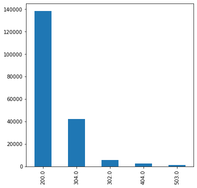

```python
# plot a bar chart of the top 5 HTTP status codes in logs.
ax = df['sc-status'].value_counts().nlargest(5).plot(kind='bar',figsize=[6,6])
```

### Allowed vs. Blocked

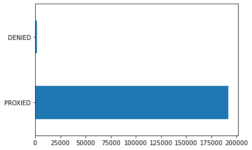

```python
df['sc-filter-result'].value_counts().plot.barh(stacked=True)
```

## User Agents

```python
# generate a unique count of the values in the "User Agent" column
df['cs(User-Agent)'].value_counts()
```

```
Mozilla/4.0 (compatible; MSIE 6.0; Windows NT 5.1; SV1; .NET CLR 1.1.4322)                                64487
Mozilla/4.0 (compatible; MSIE 6.0; Windows NT 5.1; .NET CLR 1.1.4322)                                     15321
Mozilla/4.0 (compatible; MSIE 6.0; Windows NT 5.1; SV1)                                                    9825
Mozilla/4.0 (compatible; MSIE 6.0; MSIE 5.5; Windows NT 5.1) Opera 7.01  [en]                              9099
Mozilla/5.0 (Windows; U; Windows NT 5.1; en-US; rv:1.7.7) Gecko/20050414 Firefox/1.0.3                     7382
                                                                                                          ...
ST3PS                                                                                                         1
PGP                                                                                                           1
Internet Download                                                                                             1
Pure Networks                                                                                                 1
Turbine-Launcher/1.0 (AC1 launcher=1.0.1.23 gls=1.0.1.21 patch=1.0.1.21)Accept-Encoding: gzip, deflate        1
Name: cs(User-Agent), Length: 277, dtype: int64
```

#### The above query shows a quick overview of the user-agent column, but let's print the most and least frequent values, which will be more helpful.

```python
# most frequent value
df['cs(User-Agent)'].value_counts().idxmax()
```

```
'Mozilla/4.0 (compatible; MSIE 6.0; Windows NT 5.1; SV1; .NET CLR 1.1.4322)'
```

```python
# summary - user agents where count is less than 5
temp = df['cs(User-Agent)'].value_counts() < 5
temp.tail(10).index
```

```
Index(['ZoneAlarm/5.1.011.000 ZSP/2.1', 'iPassConnect', 'msmsgs/5.0.0.381',
       'Mozilla/4.0 (compatible; MSIE 6.0)', 'Mozilla/4.01 [en] (Win95; I)',
       'ST3PS', 'PGP', 'Internet Download', 'Pure Networks',
       'Turbine-Launcher/1.0 (AC1 launcher=1.0.1.23 gls=1.0.1.21 patch=1.0.1.21)Accept-Encoding: gzip, deflate'],
      dtype='object')
```

```python
# print UA with values less than 5 - details
temp = df['cs(User-Agent)'].value_counts()[df['cs(User-Agent)'].value_counts() < 5 ]
temp
```

```
Microsoft Data Access Internet Publishing Provider Protocol Discovery                                     4
TrillianPRO/2.0 (Windows; I; 32-bit)                                                                      4
Mozilla/4.0 (compatible; MSIE 6.0; Windows NT 5.2; SV1; .NET CLR 1.1.4322)                                4
st                                                                                                        4
Shareaza 2.1.0.0                                                                                          4
Mozilla/4.0 (Windows XP 5.1) Java/1.5.0_02                                                                4
Mozilla/4.0 (compatible; Win32; WinHttp.WinHttpRequest.5)                                                 4
InetClntApp/3.0                                                                                           4
ROGUE/1.0.1                                                                                               4
Mozilla/4.0 (Windows XP 5.1) Java/1.4.2_03                                                                4
Mozilla/4.79 [en]C-CCK-MCD Boeing Kit  (Windows NT 5.0; U)                                                3
msmsgs/5.0.0.482                                                                                          3
gcTCPObjLib                                                                                               3
Travel Update                                                                                             3
Mozilla/5.0 (compatible; MSIE 5.0; Windows 98; YComp 5.3.12.0 DEFAULT)                                    3
SURFINET                                                                                                  3
iTunes/4.7.1 (Macintosh; U; PPC Mac OS X 10.3.9)                                                          3
Mozilla/5.0 (Windows; U; Windows NT 5.0; en-US; rv:1.7.6) Gecko/20050317 Firefox/1.0.2                    3
SMS CCM                                                                                                   3
Mozilla/4.0 (compatible; MSIE 6.0; Windows NT 5.0; Q312461)                                               3
WPC51AB                                                                                                   3
Mozilla/4.0 (compatible; MSIE 6.0; Windows NT 5.1; .NET CLR 1.1.4322; Google-TR-1)                        3
AppleSyndication/38                                                                                       3
OSCM2                                                                                                     3
Azureus 2.2.0.2                                                                                           3
MPFv6.0.0.14                                                                                              3
ZoneAlarm/5.1.033.000 ZSP/2.1                                                                             2
NSPlayer/10.0.0.3646 WMFSDK/10.0                                                                          2
Mozilla/4.0 (Windows XP 5.1) Java/1.5.0_01                                                                2
NSPlayer/8.0.0.4487                                                                                       2
Mozilla/4.0 (Compatible; MyWebSearch)                                                                     2
tuner/6.0.2 (Windows 2000 x86 5.1)                                                                        2
Frameset checking                                                                                         2
Mozilla/4.0 (compatible; MSIE 6.0; Windows NT 5.0; MSN Messenger 6.2.0205)                                2
jupdate                                                                                                   2
MSInvestor Ticker                                                                                         2
AIM/30 (Mozilla 1.24b; Windows; I; 32-bit)                                                                2
Mozilla/3.0 (compatible; Indy Library)                                                                    2
SAH Agent                                                                                                 2
My Session                                                                                                2
```

[output cut: 47 more lines]

```
mmjb                                                                                                      1
ROVA Update Version: 2.3.110.0, Windows XP (5.1.2600 Service Pack 1)                                      1
Mozilla/4.0 (Windows XP 5.1) Java/1.4.2_04                                                                1
IOKernel/3.1.3                                                                                            1
ZoneAlarm/5.1.011.000 ZSP/2.1                                                                             1
iPassConnect                                                                                              1
msmsgs/5.0.0.381                                                                                          1
Mozilla/4.0 (compatible; MSIE 6.0)                                                                        1
Mozilla/4.01 [en] (Win95; I)                                                                              1
ST3PS                                                                                                     1
PGP                                                                                                       1
Internet Download                                                                                         1
Pure Networks                                                                                             1
Turbine-Launcher/1.0 (AC1 launcher=1.0.1.23 gls=1.0.1.21 patch=1.0.1.21)Accept-Encoding: gzip, deflate    1
Name: cs(User-Agent), dtype: int64
```

```python
# Look for powershell, python, curl, office, shell, scan Metasploit  in the User Agents
df [df['cs(User-Agent)'].str.contains('pow|office|python|curl|shell|metasploit|bot|scan', case= False) == True]['cs(User-Agent)'].unique()
```

```
array(['Entourage/11.0 (Mac_PowerPC; DigExt; TmstmpExt)',
       'Mozilla/4.0 (compatible; MSIE 5.14; Mac_PowerPC)'], dtype=object)
```

```python
# Let's look at destination hosts count by ascending order.
df['cs-host'].value_counts(ascending=True)
```

```
download.sourceforge.net       1
civilwarclipart.com            1
nypost.com                     1
ads.nypost.com                 1
i.office.microsoft.com         1
                            ...
i.a.cnn.net                 3197
mt.google.com               3288
www.racingone.com           4219
admin.interop.com           4797
us.i1.yimg.com              7408
Name: cs-host, Length: 3577, dtype: int64
```

```python
# Let's look at destination host proxy categories by ascending order.
df['sc-filter-category'].value_counts(ascending=True)
```

```
Violence/Hate/Racism               6
Alcohol/Tobacco                   11
Pay%20to%20Surf                   20
unavailable                       20
Military                          30
Humor/Jokes                       48
Spyware/Malware%20Sources         50
Religion                          53
Restaurants/Dining/Food           84
Hacking/Proxy%20Avoidance        170
Intimate%20Apparel/Swimsuit      173
Health                           192
Sex%20Education                  201
Streaming%20Media/MP3            237
Web%20Hosting                    420
Political/Activist%20Groups      483
Vehicles                         527
Gambling                         630
Financial%20Services             654
Chat/Instant%20Messaging         710
Real%20Estate                    733
Government/Legal                 796
Adult/Mature%20Content           800
Software%20Downloads             828
Society/Lifestyle               1038
Brokerage/Trading               1425
Web%20Communications            1604
Education                       1815
Games                           1892
Job%20Search/Careers            1971
Personals/Dating                2057
Reference                       2095
Auctions                        2360
Newsgroups                      2558
Arts/Entertainment              4857
Email                           5509
Shopping                        5534
Travel                          7456
Sports/Recreation/Hobbies       8967
Search%20Engines/Portals       12320
Pornography                    12325
none                           14089
Business/Economy               16525
Computers/Internet             21334
News/Media                     22059
Web%20Advertisements           36039
Name: sc-filter-category, dtype: int64
```

#### We see some interesting categories above like "Spyware/Malware%20Sources". Let's see which domains are associated with this category.

```python
df[df['sc-filter-category'] == "Spyware/Malware%20Sources"]['cs-host'].unique()
```

```
array(['webpdp.gator.com', 'www.shopathomeselect.com',
       'promos.hotbar.com', 'pub.weatherbug.com', 'wwc.weatherbug.com',
       'www.internet-optimizer.com', 'isapi60.wxbug.com',
       'www.funwebproducts.com', 'friendfinder.com',
       'help.internet-optimizer.com'], dtype=object)
```

#### A couple of the above results for "Spyware/Malware%20Sources" category domains appear suspicious such as "www[.]internet-optimizer[.]com". Let's do another search where we pull all domains that contain the words "mal", "Mal", "bot", "spy" in their category.

```python
df [ df['sc-filter-category'].str.contains('mal|Mal|bot|spy',case=False) == True]['cs-host'].value_counts()
```

```
isapi60.wxbug.com              19
webpdp.gator.com                8
www.shopathomeselect.com        7
friendfinder.com                4
www.funwebproducts.com          3
promos.hotbar.com               2
wwc.weatherbug.com              2
www.internet-optimizer.com      2
help.internet-optimizer.com     2
pub.weatherbug.com              1
Name: cs-host, dtype: int64
```

### Let's use whois and see when above hosts were created

```python
temp = df [ df ['sc-filter-category'].str.contains('mal|Mal|bot|spy',case=False) == True]['cs-host'].unique()

for i in temp:
    c_date =  str ( whois.whois(i).creation_date )
    print(i + "\t" + c_date)
```

```
webpdp.gator.com	1997-03-19 05:00:00
www.shopathomeselect.com	[datetime.datetime(2001, 5, 23, 17, 19, 15), datetime.datetime(2001, 5, 23, 0, 0)]
promos.hotbar.com	[datetime.datetime(1998, 9, 1, 4, 0), datetime.datetime(2011, 8, 21, 6, 40, 37)]
pub.weatherbug.com	1999-09-20 16:32:56
wwc.weatherbug.com	1999-09-20 16:32:56
www.internet-optimizer.com	[datetime.datetime(2002, 12, 19, 18, 16, 12), datetime.datetime(2002, 12, 19, 13, 16, 12)]
isapi60.wxbug.com	2000-04-05 19:58:40
www.funwebproducts.com	2003-06-18 18:42:09
friendfinder.com	[datetime.datetime(1998, 3, 5, 5, 0), datetime.datetime(1998, 3, 5, 0, 0)]
help.internet-optimizer.com	[datetime.datetime(2002, 12, 19, 18, 16, 12), datetime.datetime(2002, 12, 19, 13, 16, 12)]
```

#### Looks like these domains are created a while back. So, let's move on for now to looking at the "unavailable" category; these could be more interesting.

```python
df[df['sc-filter-category'] == "unavailable"]['cs-host'].unique()
```

```
array(['-', 'www.hawkeyedraintile.com'], dtype=object)
```

#### So looking at the "unavailable" category events above, we only get one hit, which is suspicious. So let's learn more details related to this domain.

```python
# lets look at 'c-ip' for the 'unavailable' category
df[df['sc-filter-category'] == "unavailable"]['c-ip'].unique()
```

```
array(['45.25.2.252', '45.14.5.248', '45.14.5.240', '45.14.4.114',
       '45.14.5.160', '45.14.5.103', '45.0.18.252', '45.25.4.252'],
      dtype=object)
```

```python
## If you have access to an intel feed's API, you could take above IPs and enrich through it.
```

```python
df[df['sc-filter-category'] == "unavailable"]['cs(User-Agent)'].value_counts(ascending=True)
```

```
Shareaza 2.1.0.0                                                                           1
Mozilla/4.0 (compatible; MSIE 6.0; Windows NT 5.1; SV1; .NET CLR 1.1.4322)                 2
Mozilla/5.0 (Windows; U; Windows NT 5.1; en-US; rv:1.7.7) Gecko/20050414 Firefox/1.0.3     2
-                                                                                         15
Name: cs(User-Agent), dtype: int64
```

#### In the result above, we get one unusual user-agent: "Shareaza 2.1.0.0". And when you research this, it appears to be related to "A universal P2P file sharing client for Windows"

#### Let's capture where which IP is observed using "Shareaza" UA and likely has that P2P client installed

```python
df [(df['cs(User-Agent)'] == 'Shareaza 2.1.0.0')][['date', 'sc-filter-result', 'cs-method', 'c-ip','cs-host','cs-bytes' ,'sc-filter-category']]
```

|  | date | sc-filter-result | cs-method | c-ip | cs-host | cs-bytes | sc-filter-category |
| --- | --- | --- | --- | --- | --- | --- | --- |
| 128049 | 2005-05-06 | PROXIED | GNUTELLA | 45.25.4.252 | - | 346.0 | unavailable |
| 148448 | 2005-05-06 | DENIED | GET | 45.25.4.252 | tobiasserver.ath.cx | 266.0 | Business/Economy |
| 148842 | 2005-05-06 | PROXIED | GET | 45.25.4.252 | empire-hosting.net | 240.0 | Pornography |
| 148846 | 2005-05-06 | PROXIED | GET | 45.25.4.252 | lowesthost.com | 218.0 | none |

#### Let's move from the proxy category and start looking at IP addresses.

#### First, I want to use a regex to pull all public IP addresses from the 'cs-host' and their "sc-status"

```python
# Public IP addresses only & their HTTP Response status code
df [ df['cs-host'].str.contains(r'\b(?!(10)|192\.168|172\.(2[0-9]|1[6-9]|3[0-1])|(25[6-9]|2[6-9][0-9]|[3-9][0-9][0-9]|99[1-9]))[0-9]{1,3}\.(25[0-5]|2[0-4][0-9]|[01]?[0-9][0-9]?)\.(25[0-5]|2[0-4][0-9]|[01]?[0-9][0-9]?)\.(25[0-5]|2[0-4][0-9]|[01]?[0-9][0-9]?)') == True ][['cs-host','sc-status']]
```

|  | cs-host | sc-status |
| --- | --- | --- |
| 815 | 216.169.154.137 | 200.0 |
| 866 | 216.169.154.137 | 200.0 |
| 954 | 216.169.154.137 | 304.0 |
| 999 | 216.169.154.137 | 200.0 |
| 1000 | 216.169.154.137 | 200.0 |
| 1001 | 216.169.154.137 | 200.0 |
| 1118 | 216.169.154.137 | 200.0 |
| 1126 | 216.169.154.137 | 200.0 |
| 1261 | 216.169.154.137 | 200.0 |
| 1467 | 149.174.36.116 | 200.0 |
| 1468 | 149.174.36.116 | 200.0 |
| 1470 | 149.174.36.116 | 200.0 |
| 1472 | 149.174.36.116 | 200.0 |
| 1474 | 149.174.36.116 | 200.0 |
| 1475 | 149.174.36.116 | 200.0 |
| 1476 | 149.174.36.116 | 200.0 |
| 1477 | 149.174.36.116 | 200.0 |
| 1478 | 149.174.36.116 | 200.0 |
| 1479 | 149.174.36.116 | 200.0 |
| 1481 | 149.174.36.116 | 200.0 |
| 1482 | 149.174.36.116 | 200.0 |
| 1483 | 149.174.36.116 | 200.0 |
| 1484 | 149.174.36.116 | 200.0 |
| 1485 | 149.174.36.116 | 200.0 |
| 1487 | 149.174.36.116 | 200.0 |
| 1488 | 149.174.36.116 | 200.0 |
| 1492 | 149.174.36.116 | 200.0 |
| 1493 | 149.174.36.116 | 200.0 |
| 1494 | 149.174.36.116 | 200.0 |
| 1495 | 149.174.36.116 | 200.0 |

[output cut: 1666 more lines]

```python
# Public IP addresses only
df [ df['cs-host'].str.contains(r'\b(?!(10)|192\.168|172\.(2[0-9]|1[6-9]|3[0-1])|(25[6-9]|2[6-9][0-9]|[3-9][0-9][0-9]|99[1-9]))[0-9]{1,3}\.(25[0-5]|2[0-4][0-9]|[01]?[0-9][0-9]?)\.(25[0-5]|2[0-4][0-9]|[01]?[0-9][0-9]?)\.(25[0-5]|2[0-4][0-9]|[01]?[0-9][0-9]?)') == True ]['cs-host'].unique()
```

```
array(['216.169.154.137', '149.174.36.116', '45.28.0.30', '68.142.139.60',
       '192.33.62.106', '67.19.211.138', '67.19.211.114', '70.84.241.186',
       '161.58.81.177', '70.84.241.234', '70.84.241.250',
       '68.165.147.253', '159.161.137.42', '129.37.0.113',
       '198.104.142.51', '136.151.233.11', '204.146.166.107',
       '208.219.220.204', '32.97.118.242', '212.72.11.166',
       '207.61.242.85', '203.199.70.171', '203.199.70.249',
       '192.16.170.44', '203.199.70.237', '157.54.4.22', '66.45.111.1',
       '66.151.136.18', '66.102.7.104', '64.158.218.149',
       '209.197.108.169', '66.39.90.240', '207.44.238.18',
       '207.234.144.94', '195.41.47.82', '65.219.61.150', '64.69.70.158',
       '24.234.200.1', '66.162.189.124', '66.70.65.210', '69.56.176.76',
       '132.233.247.5', '64.4.43.250', '69.31.37.42', '70.84.241.226',
       '80.85.71.33', '62.26.121.2', '64.255.164.70', '143.166.99.131',
       '65.54.244.250', '207.114.199.161', '66.151.158.177',
       '65.74.147.41', '212.209.238.220', '64.237.62.210',
       '216.158.129.18', '202.107.228.156', '130.65.61.5', '67.18.2.212',
       '24.120.212.1', '217.193.154.123', '213.8.137.51', '80.179.136.4',
       '192.118.68.93', '66.230.141.82', '64.237.44.62', '62.73.174.194',
       '209.8.25.179', '62.189.244.254', '209.73.229.216',
       '213.132.120.42', '128.83.40.22', '207.46.110.30', '64.34.66.21',
       '64.236.34.97', '198.65.164.168', '69.88.147.113', '63.217.31.74',
       '205.177.122.83', '70.84.241.242', '70.84.227.226',
       '205.188.214.34', '207.200.96.50', '80.81.172.232',
       '216.250.230.21', '24.120.208.1', '206.225.85.37', '132.233.247.7',
       '69.28.230.72', '67.19.9.2'], dtype=object)
```

#### Lets now look at traffic where HTTP Method is "POST" or "PUT" sugguesting a possible exfil

```python
# HTTP "POST" or "PUT". The output table will include ip, host, bytes and category
df [(df['cs-method'] == 'POST') | (df['cs-method'] == 'PUT')][['c-ip','cs-host','cs-bytes' ,'sc-filter-category']]
```

|  | c-ip | cs-host | cs-bytes | sc-filter-category |
| --- | --- | --- | --- | --- |
| 95 | 10.0.1.2 | register.ositis.com | 700.0 | none |
| 96 | 10.0.1.2 | register.ositis.com | 749.0 | none |
| 1162 | 10.2.13.59 | 10.2.13.200 | 699.0 | none |
| 1365 | 10.2.13.59 | reporter.bluecoat.com | 810.0 | none |
| 1995 | 10.0.1.2 | register.ositis.com | 698.0 | none |
| 1996 | 10.0.1.2 | register.ositis.com | 762.0 | none |
| 2060 | 10.0.1.2 | register.ositis.com | 702.0 | none |
| 2061 | 10.0.1.2 | register.ositis.com | 763.0 | none |
| 2073 | 10.0.1.4 | stats.update.microsoft.com | 2721.0 | none |
| 2130 | 10.0.1.2 | register.ositis.com | 698.0 | none |
| 2131 | 10.0.1.2 | register.ositis.com | 741.0 | none |
| 2177 | 10.0.1.4 | stats.update.microsoft.com | 2721.0 | none |
| 2186 | 10.0.1.2 | register.ositis.com | 710.0 | none |
| 2187 | 10.0.1.2 | register.ositis.com | 765.0 | none |
| 2247 | 10.0.1.2 | register.ositis.com | 692.0 | none |
| 2248 | 10.0.1.2 | register.ositis.com | 760.0 | none |
| 2281 | 10.0.1.4 | stats.update.microsoft.com | 2721.0 | none |
| 2317 | 10.0.1.2 | register.ositis.com | 705.0 | none |
| 2318 | 10.0.1.2 | register.ositis.com | 780.0 | none |
| 2394 | 10.0.1.2 | register.ositis.com | 695.0 | none |
| 2395 | 10.0.1.2 | register.ositis.com | 779.0 | none |
| 2422 | 10.0.1.4 | stats.update.microsoft.com | 2721.0 | none |
| 2536 | 10.2.13.59 | reporter.bluecoat.com | 709.0 | none |
| 2558 | 10.2.13.59 | reporter.bluecoat.com | 787.0 | none |
| 2728 | 10.2.13.200 | watchdog.bluecoat.com | 703.0 | none |
| 2741 | 10.2.13.200 | watchdog.bluecoat.com | 783.0 | none |
| 2745 | 10.2.13.200 | watchdog.bluecoat.com | 787.0 | none |
| 2753 | 10.2.13.200 | watchdog.bluecoat.com | 769.0 | none |
| 3381 | 10.2.13.200 | watchdog.bluecoat.com | 703.0 | none |
| 3393 | 10.2.13.200 | watchdog.bluecoat.com | 787.0 | none |

[output cut: 1943 more lines]

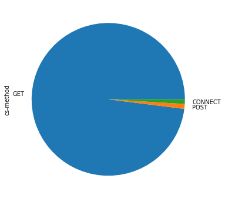

```python
# plot a pie chart of the top 3 HTTPS Methods observed in logs
df['cs-method'].value_counts().nlargest(3).plot(kind='pie',figsize=[6,6])
```

#### Let's drill down further in exfil question and show hosts where max data appears to have been uploaded

```python
temp = df.groupby('cs-host').sum().sort_values('cs-bytes',ascending=False)
temp [ temp > 1000000 ]['cs-bytes'].sort_values(ascending=False)
# df.dropna()
## you can remove the NaN (not a number) but it will take long time
```

```
cs-host
netmail.verizon.net                                     5502012.0
us.i1.yimg.com                                          2952907.0
rad.msn.com                                             2608012.0
www.racingone.com                                       2316307.0
forums.offtopic.com                                     1972109.0
mt.google.com                                           1816953.0
games.espn.go.com                                       1614433.0
watchdog.bluecoat.com                                   1354826.0
kh.google.com                                           1314420.0
i.a.cnn.net                                             1242429.0
images.rei.com                                          1235400.0
a1072.g.akamai.net                                      1199860.0
www.aa.com                                              1078188.0
us.f212.mail.yahoo.com                                  1056451.0
wcp.getthere.net                                        1030689.0
wwwimage.cbs.com                                        1015164.0
admin.interop.com                                             NaN
www.classmates.com                                            NaN
ar.atwola.com                                                 NaN
bc.us.yahoo.com                                               NaN
static.eharmony.com                                           NaN
exchange.hire.com                                             NaN
as.cmpnet.com                                                 NaN
ad.doubleclick.net                                            NaN
www.microsoft.com                                             NaN
m3.doubleclick.net                                            NaN
www.verisign.com                                              NaN
thumbs.ebaystatic.com                                         NaN
www.comcast.net                                               NaN
pagead2.googlesyndication.com                                 NaN
img.dell.com                                                  NaN
email.email.secureserver.net                                  NaN
webmail.att.net                                               NaN
www.cisco.com                                                 NaN
amch.questionmarket.com                                       NaN
by102fd.bay102.hotmail.msn.com                                NaN
www.azcentral.com                                             NaN
www.cbs.com                                                   NaN
image.weather.com                                             NaN
```

[output cut: 3524 more lines]

```
ausdcamer17                                                   NaN
ntva344dc02                                                   NaN
www.gsinform.com                                              NaN
ausdsrr505                                                    NaN
ausdspc103                                                    NaN
avu.zonelabs.com                                              NaN
i2                                                            NaN
update.pgp.com                                                NaN
download.lavasoft.de                                          NaN
132.233.247.7                                                 NaN
sc.musicmatch.com                                             NaN
www.gemtek.com.tw                                             NaN
www.kimo.com.tw                                               NaN
66.151.158.177                                                NaN
Name: cs-bytes, dtype: float64
```

### Let's review the HTTP Response "Content-Type" Field

```python
# List of content
df['rs(Content-Type)'].unique()
```

```
array(['text/html', 'application/octet-stream', '-', 'image/gif',
       'image/jpeg', 'text/html;%20charset=iso-8859-1', 'text/css',
       'image/png', 'text/plain;%20charset=iso-8859-1',
       'application/x-javascript', 'image/x-icon',
       'text/html;%20charset=ISO-8859-1', None,
       'text/html;%20charset=UTF-8', 'text/javascript;%20charset=UTF-8',
       'application/pkix-crl', 'text/rdf', 'text/xml;%20charset=utf-8',
       'application/zip', 'text/plain', 'application/pdf',
       'text/javascript', 'application/x-shockwave-flash',
       'text/plain;%20charset=ISO-8859-1', 'text/html;charset=ISO-8859-1',
       'text/html;%20charset=utf-8',
       'application/x-javascript;%20charset=iso-8859-1',
       'text/css;%20charset=iso-8859-1', 'application/x-pointplus',
       'text/xml', 'video/quicktime', 'image/pjpeg',
       'text/plain;%20charset=UTF-8', 'text/html;%20Charset=utf-8',
       'text/xml;%20charset=iso-8859-1', 'GCZ',
       'application/vnd.ms-pki.seccat', 'text/html;charset=UTF-8',
       'text/css;%20charset=utf-8', 'text/javascript;%20charset=utf-8',
       'text/html;%20charset=Windows-1252',
       'text/javascript;%20charset=ISO-8859-1',
       'text/html;%20charset=US-ASCII',
       'application/x-javascript;%20charset=ISO-8859-1',
       'text/css;%20charset=ISO-8859-1', 'text/xml;%20charset=UTF-8',
       'text/html;charset=utf-8', 'text/javascript;charset=ISO-8859-1',
       'text/html;charset=iso-8859-1', 'text/js', 'image/jpg',
       'text/plain;%20charset=utf-8', 'application/x-httpd-php',
       'application/x-java-jnlp-file', 'application/x-java-archive',
       'text/html;%20charset=windows-1252', 'application/rss+xml',
       'text/html;%20charset=windows-1255', 'application/xml', '*/*',
       'text/css;charset=utf-8', 'text/javascript;charset=utf-8',
       'text/x-component', 'application/x-javascript;%20charset=utf-8',
       'text/html;charset=646', 'text/html;%20charset=%22iso-8859-1%22',
       'image/gif;', 'image/gif;%20filename=%22foo.bar%22',
       'multipart/byteranges;%20boundary=<q1w2e3r4t5y6u7i8o9p0zaxscdvfbgnhmjklkl>',
       'image/GIF', 'application/java-archive',
       'image/gif;%20name=%22shamrok_gitarsLine.gif%22', 'text/script',
       'application/x-ica', 'text/x-setext',
       'application/vnd.ms-powerpoint', 'application/rdf+xml',
       'image/jpeg;%20name=banner_13.jpeg', 'cnn/user-cookie',
       'application/qfn-encoded', 'image/bmp',
```

[output cut: 76 more lines]

```
       'image/jpeg;%20name=9e34eaff8a6e858da811114303f3554c.jpeg',
       'image/gif;%20name=7428b631925238dfb68011fbbecb2fbf.gif',
       'image/jpeg;%20name=5033a64ad6fabe81140f13e6ce139c0f.jpeg',
       'image/gif;%20name=d3655a79f110b56ebd1c077a880a537e.gif',
       'application/x-www-urlform-encoded',
       'image/gif;%20name=9b409769f3cea55d3c4a43ebfa1bb24a.gif',
       'image/gif;%20name=0c252475b8c9381e7b2cf8bb6f72a97f.gif',
       'image/gif;%20name=f7d390a4c2faa3f70288ba13fd8570aa.gif',
       'image/gif;%20name=520196cbdc4d66b54dfa279d1c0dc313.gif',
       'image/gif;%20name=4140c3e72df8c793ec5da45e825bc46e.gif',
       'image/gif;%20name=5d6f2b82866a48a0fc049ccabb81ea3e.gif',
       'image/gif;%20name=dishstorebanner001.gif', 'application/x-amf',
       'text/html;%20charset=%22%22', 'text/html;%20charset=shift_jis',
       'text/html;%20charset=iso-2022-jp',
       'text/html;%20charset=Shift_JIS'], dtype=object)
```

```python
# The HTTP POST method uses 'application/x-www-urlform-encoded' to upload data. Let's see which host do we see this with.
df [ ( df['rs(Content-Type)'] == 'application/x-www-urlform-encoded' ) == True ]['cs-host'].unique()
```

```
array(['www.clocklink.com'], dtype=object)
```

```python
# When executables are downloaded, this content type is 'application/octate-stream'. Let's see which host do we see this with.
df [ (df['rs(Content-Type)'] == 'application/octate-stream') == True ]
```

|  | date | time | time-taken | c-ip | sc-status | s-action | sc-bytes | cs-bytes | cs-method | cs-uri-scheme | cs-host | cs-uri-path | cs-uri-query | cs-username | s-hierarchy | s-supplier-name | rs(Content-Type) | cs(User-Agent) | sc-filter-result | sc-filter-category | x-virus-id | s-ip | s-sitename | x-virus-details | x-icap-error-code | x-icap-error-details |
| --- | --- | --- | --- | --- | --- | --- | --- | --- | --- | --- | --- | --- | --- | --- | --- | --- | --- | --- | --- | --- | --- | --- | --- | --- | --- | --- |

```python
# Are there any images file types with unusual Content-Types?
df[ (df['cs-uri-path'].str.contains('png|PNG') ) & ( df['rs(Content-Type)'] == 'application/octate-stream') ]['rs(Content-Type)']
```

```
Series([], Name: rs(Content-Type), dtype: object)
```

# Interactive Report

```python
profile = ProfileReport(df, title="Web Proxy Logs Hunt", explorative=True)
```

```python
#profile.to_widgets()
profile.to_notebook_iframe()
```

[interactive chart not shown]

```python
#Thanks! Another happy hunting session!
```